# [PADP 8400]: Extra Credit

Bradley Howard

### [PADP 8400]: Extra Credit

For these exercises we will be using the Global Terrorism Database (GTD) which can be found on Kaggle: https://www.kaggle.com/START-UMD/gtd/data. The GTD contains a great deal of information about terrorist events and contains roughly 170,000 such events.

### Due Date and Time

Due on Monday, November 22nd at 11:59PM

### Guidelines

All extra credit assignments must be submitted as two files:

1. A *R Markdown* file with the following format: “lastname_firstname_extra_credit.Rmd”.
2. A compiled *R Markdown* file in HTML with the following format: “lastname_firstname_extra_credit.html”

Please only fill in the sections labelled “YOUR CODE HERE”

### Learning about assassinations and bombings through random forests

For this problem set, we will be taking the training wheels off and you will have to use your discretion to train a model using random forests, a variant of decision trees.

The goal of this portion of the assignment is to build a machine learning classifier that will enable you to predict assasination events as a function of the features in the data.

Assassinations are labeled as “1” in the variable “attacktype1” within the GTD and bombings are labeled as “3”. Using whichever features you would like and whichever package you wouldu like, train two random forest classifiers to predict assassinations and bombings using an 80/20 training test split.

Report the: accuracy, specificity and sensitivity of the classifiers that you trained for each model.

```r
### Code for assasinations classifier
##### YOUR CODE HERE ###################################
library(pacman)

pacman::p_load(tm,SnowballC,foreign,RCurl,plyr,slam,foreign,wordcloud,LiblineaR,e1071,caret,ranger,rpart,rpart.plot)
data <- read.csv("gtd_edited_nona.csv")

#create assassination predicted variable from attack type
data$assassination <- 0
#label all assassinations as 1, 0 otherwise for new feature
data$assassination[data$attacktype1 == 1] <- 1



#generates the random indices. creates 80/20 train-test data
index = sample(nrow(data), 0.8* nrow(data))

data_traina = data[index,] # Training data
data_testa = data[-index,] # Test data



rf_assassinations <- ranger(factor(assassination) ~.-attacktype1 -bombing -attacktype1_txt -provstate -corp1 -X, data=data_traina,
                            importance = 'impurity',
                            write.forest = T,
                            probability = T
                           )
rf_probs <- predict(rf_assassinations, data_testa)

rf_class<-ifelse(rf_probs$predictions[,2] > 0.3, 1,0)

predicted_class = factor(rf_class)
true_class = factor(data_testa$assassination)

cmat = confusionMatrix(predicted_class,true_class, positive = "1")
cmat
```

```
## Confusion Matrix and Statistics
##
##           Reference
## Prediction     0     1
##          0 27959   943
##          1  1806  2587
##
##                Accuracy : 0.9174
##                  95% CI : (0.9144, 0.9204)
##     No Information Rate : 0.894
##     P-Value [Acc > NIR] : < 2.2e-16
##
##                   Kappa : 0.6068
##
##  Mcnemar's Test P-Value : < 2.2e-16
##
##             Sensitivity : 0.7329
##             Specificity : 0.9393
##          Pos Pred Value : 0.5889
##          Neg Pred Value : 0.9674
##              Prevalence : 0.1060
##          Detection Rate : 0.0777
##    Detection Prevalence : 0.1319
##       Balanced Accuracy : 0.8361
##
##        'Positive' Class : 1
##
```

```r
##### YOUR CODE HERE ###################################
```

```r
### Code for bombings classifier
##### YOUR CODE HERE ###################################

#create bombing predicted variable from attack type
data$bombing <- 0
#label all bombings as 1, otherwise 0 for new feature
data$bombing[data$attacktype1 == 3] <-1

index = sample(nrow(data), 0.8* nrow(data))

data_trainb = data[index,] # Training data
data_testb = data[-index,] # Test data

rf_bombings <- ranger(factor(bombing) ~.-attacktype1 -assassination -attacktype1_txt -provstate -corp1 -X, data=data_trainb,
                            importance = 'impurity',
                            write.forest = T,
                            probability = T,
                      num.trees = 600
                           )
rf_probs <- predict(rf_bombings, data_testb)

rf_class<-ifelse(rf_probs$predictions[,2] > 0.5, 1,0)

predicted_class = factor(rf_class)
true_class = factor(data_testb$bombing)

cmat_b = confusionMatrix(predicted_class,true_class, positive = "1")
cmat_b
```

```
## Confusion Matrix and Statistics
##
##           Reference
## Prediction     0     1
##          0 15867  6239
##          1  1593  9596
##
##                Accuracy : 0.7648
##                  95% CI : (0.7602, 0.7693)
##     No Information Rate : 0.5244
##     P-Value [Acc > NIR] : < 2.2e-16
##
##                   Kappa : 0.5219
##
##  Mcnemar's Test P-Value : < 2.2e-16
##
##             Sensitivity : 0.6060
##             Specificity : 0.9088
##          Pos Pred Value : 0.8576
##          Neg Pred Value : 0.7178
##              Prevalence : 0.4756
##          Detection Rate : 0.2882
##    Detection Prevalence : 0.3361
##       Balanced Accuracy : 0.7574
##
##        'Positive' Class : 1
##
```

```r
##### YOUR CODE HERE ###################################
```

### 2. Which features predict assasinations and bombings best?

One of the best things about the random forests algorithm is that it allows us to understand which features contributed most to prediction success.

Create a plot of the top 10 most important features for each classifier using the % increase in MSE estimate to determine feature importance.

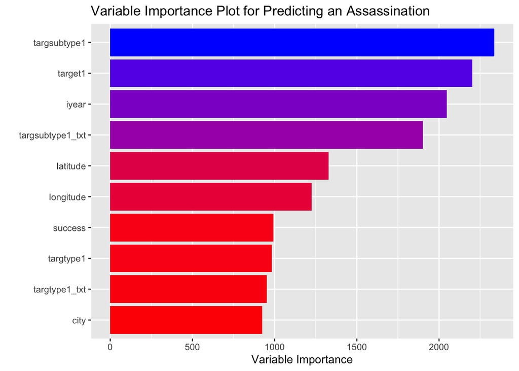

```r
### Plot for assasinations classifier
##### YOUR CODE HERE ###################################

varimp_a = rf_assassinations$variable.importance #get variable importance
words_a<-names(varimp_a)
importance_a<-as.vector(varimp_a)

# Create a data frame with both words and their importance
importance.data_a = data.frame(words_a,importance_a)

# Now we need to reorder the data frame in descending order
# and select top 10

importance.data_a = importance.data_a[order(-importance.data_a$importance),]
importance.data_a = importance.data_a[1:10,]


# Plot variable importance
a_plot <-ggplot(importance.data_a,
       aes(x=reorder(words_a,importance_a), y=importance_a,fill=importance_a))+
  geom_bar(stat="identity", position="dodge")+ coord_flip()+
  ylab("Variable Importance")+
  xlab("")+
  ggtitle("Variable Importance Plot for Predicting an Assassination")+
  guides(fill=F)+
  scale_fill_gradient(low="red", high="blue")

a_plot
```

```r
##### YOUR CODE HERE ###################################
```

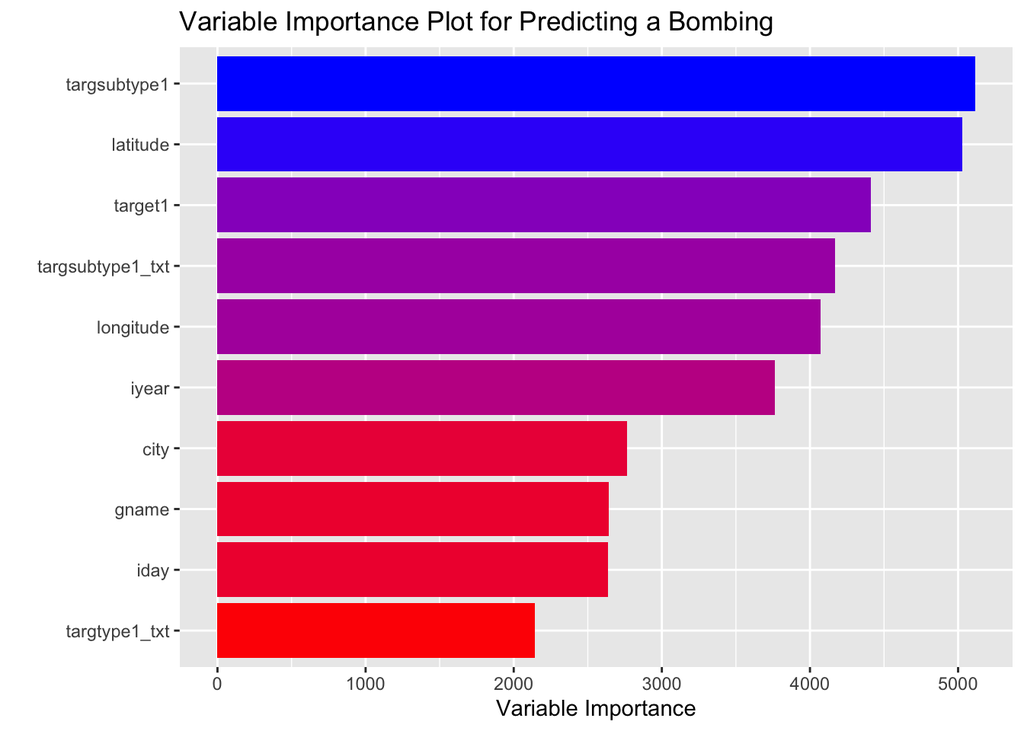

```r
### Plot for bombings classifier
##### YOUR CODE HERE ###################################
varimp_b = rf_bombings$variable.importance
words_b<-names(varimp_b)
importance_b<-as.vector(varimp_b)

# Create a data frame with both words and their importance
importance.data_b = data.frame(words_b,importance_b)

# Now we need to reorder the data frame in descending order
# and select top 10

importance.data_b = importance.data_b[order(-importance.data_b$importance),]
importance.data_b = importance.data_b[1:10,]


# Plot variable importance
b_plot <-ggplot(importance.data_b,
       aes(x=reorder(words_b,importance_b), y=importance_b,fill=importance_b))+
  geom_bar(stat="identity", position="dodge")+ coord_flip()+
  ylab("Variable Importance")+
  xlab("")+
  ggtitle("Variable Importance Plot for Predicting a Bombing")+
  guides(fill=F)+
  scale_fill_gradient(low="red", high="blue")

b_plot
```

```r
##### YOUR CODE HERE ###################################
```